# datacheck2

East

06/25/2021

```r
#Load package and data
library(tidyverse)
library(here)
raw_data_combined <- read_csv(here("outcome/raw_data_combined.csv"))[,-1]
districts <- read_csv(here("outcome/downloads/districts.csv"))
district_wise <- read_csv(here("outcome/downloads/district_wise.csv"))[,-1]

states <- read_csv(here("outcome/downloads/states.csv"))
state_wise <- read_csv(here("outcome/downloads/state_wise.csv"))
state_wise_daily <- read_csv(here("outcome/downloads/state_wise_daily.csv"))
```

# Check 0.

In`raw_data_combined`, I found by chance that the district name ‘Hamirpur’ is in two states, which are ‘Himachal Pradesh’ and ‘Uttar Pradesh’. Let’s check if there are more those district names.

```r
#Get the list of those district names and the corresponding number of states that have the district.
raw_data_combined %>% group_by(detected_district, detected_state) %>% summarise(n = n()) %>%
  group_by(detected_district) %>% summarise(n = n()) %>% filter(n >1)
```

```
## # A tibble: 18 x 2
##    detected_district      n
##    <chr>              <int>
##  1 Airport Quarantine     2
##  2 Amravati               2
##  3 Aurangabad             2
##  4 Balrampur              2
##  5 Bilaspur               2
##  6 Changlang              2
##  7 Foreign Evacuees       3
##  8 Hamirpur               2
##  9 Italians               2
## 10 Kishanganj             2
## 11 Mandi                  2
## 12 Other state            2
## 13 Other State           14
## 14 Others                 3
## 15 Pratapgarh             2
## 16 Unknown                4
## 17 Yadgir                 2
## 18 <NA>                  37
```

From the output above, it looks like there are two states having the district name Amravati. Also, two states having Aurangabad. Let’s get the state names corresponding to those districts.

```r
#state names corresponding to districts
multiple_dist <- raw_data_combined %>% group_by(detected_district, detected_state) %>% summarise(n = n()) %>%
  group_by(detected_district) %>% summarise(n = n()) %>% filter(n >1)
multiple_dist$states <- NA
for (i in 1:nrow(multiple_dist)) {
  dist <- multiple_dist$detected_district[i]
  multiple_dist$states[i] <-
    raw_data_combined %>% group_by(detected_district, detected_state) %>% summarise(n = n()) %>%
    filter(detected_district == dist) %>% .$detected_state %>% list()
}
multiple_dist$states2 <- lapply(multiple_dist$states, function(x) paste0(x, collapse = ", ")) %>%
  unlist()
multiple_dist
```

```
## # A tibble: 18 x 4
##    detected_district      n states   states2
##    <chr>              <int> <list>   <chr>
##  1 Airport Quarantine     2 <chr [2~ "Assam, Tamil Nadu"
##  2 Amravati               2 <chr [2~ "Maharashtra, NA"
##  3 Aurangabad             2 <chr [2~ "Bihar, Maharashtra"
##  4 Balrampur              2 <chr [2~ "Chhattisgarh, Uttar Pradesh"
##  5 Bilaspur               2 <chr [2~ "Chhattisgarh, Himachal Pradesh"
##  6 Changlang              2 <chr [2~ "Arunachal Pradesh, NA"
##  7 Foreign Evacuees       3 <chr [3~ "Andhra Pradesh, Haryana, Telangana"
##  8 Hamirpur               2 <chr [2~ "Himachal Pradesh, Uttar Pradesh"
##  9 Italians               2 <chr [2~ "Haryana, Rajasthan"
## 10 Kishanganj             2 <chr [2~ "Assam, Bihar"
## 11 Mandi                  2 <chr [2~ "Himachal Pradesh, Madhya Pradesh"
## 12 Other state            2 <chr [2~ "Gujarat, Rajasthan"
## 13 Other State           14 <chr [1~ "Andhra Pradesh, Assam, Bihar, Chhattisgar~
## 14 Others                 3 <chr [3~ "Assam, Nagaland, Odisha"
## 15 Pratapgarh             2 <chr [2~ "Rajasthan, Uttar Pradesh"
## 16 Unknown                4 <chr [4~ "Chhattisgarh, Gujarat, Jammu and Kashmir,~
## 17 Yadgir                 2 <chr [2~ "Karnataka, Telangana"
## 18 <NA>                  37 <chr [0~ ""
```

The following results show that the NAs in `states` for Amravati and Changlang are apparently error. Let’s fill them.

```r
#The following two state values(NA) are apparently error.
raw_data_combined %>% group_by(detected_district, detected_state) %>% summarise(n = n()) %>%
  filter(detected_district == "Amravati")
```

```
## # A tibble: 2 x 3
## # Groups:   detected_district [1]
##   detected_district detected_state     n
##   <chr>             <chr>          <int>
## 1 Amravati          Maharashtra     1043
## 2 Amravati          <NA>               1
```

```r
raw_data_combined %>% group_by(detected_district, detected_state) %>% summarise(n = n()) %>%
  filter(detected_district == "Changlang")
```

```
## # A tibble: 2 x 3
## # Groups:   detected_district [1]
##   detected_district detected_state        n
##   <chr>             <chr>             <int>
## 1 Changlang         Arunachal Pradesh   462
## 2 Changlang         <NA>                  1
```

```r
#Let's fill them.
raw_data_combined[raw_data_combined$detected_district == "Amravati" &
                    !(is.na(raw_data_combined$detected_district))&
                    is.na(raw_data_combined$detected_state),]$detected_state <- "Maharashtra"

raw_data_combined[raw_data_combined$detected_district == "Changlang" &
                    !(is.na(raw_data_combined$detected_district))&
                    is.na(raw_data_combined$detected_state),]$detected_state <- "Arunachal Pradesh"

#Let's get the district names in multiple states again.
multiple_dist <- raw_data_combined %>% group_by(detected_district, detected_state) %>% summarise(n = n()) %>%
  group_by(detected_district) %>% summarise(n = n()) %>% filter(n >1)
multiple_dist$states <- NA
for (i in 1:nrow(multiple_dist)) {
  dist <- multiple_dist$detected_district[i]
  multiple_dist$states[i] <-
    raw_data_combined %>% group_by(detected_district, detected_state) %>% summarise(n = n()) %>%
    filter(detected_district == dist) %>% .$detected_state %>% list()# paste0(kk ,sep = " ", collapse="/ ")
}
multiple_dist$states2 <- lapply(multiple_dist$states, function(x) paste0(x, collapse = ", ")) %>%
  unlist()

multiple_dist
```

```
## # A tibble: 16 x 4
##    detected_district      n states   states2
##    <chr>              <int> <list>   <chr>
##  1 Airport Quarantine     2 <chr [2~ "Assam, Tamil Nadu"
##  2 Aurangabad             2 <chr [2~ "Bihar, Maharashtra"
##  3 Balrampur              2 <chr [2~ "Chhattisgarh, Uttar Pradesh"
##  4 Bilaspur               2 <chr [2~ "Chhattisgarh, Himachal Pradesh"
##  5 Foreign Evacuees       3 <chr [3~ "Andhra Pradesh, Haryana, Telangana"
##  6 Hamirpur               2 <chr [2~ "Himachal Pradesh, Uttar Pradesh"
##  7 Italians               2 <chr [2~ "Haryana, Rajasthan"
##  8 Kishanganj             2 <chr [2~ "Assam, Bihar"
##  9 Mandi                  2 <chr [2~ "Himachal Pradesh, Madhya Pradesh"
## 10 Other state            2 <chr [2~ "Gujarat, Rajasthan"
## 11 Other State           14 <chr [1~ "Andhra Pradesh, Assam, Bihar, Chhattisgar~
## 12 Others                 3 <chr [3~ "Assam, Nagaland, Odisha"
## 13 Pratapgarh             2 <chr [2~ "Rajasthan, Uttar Pradesh"
## 14 Unknown                4 <chr [4~ "Chhattisgarh, Gujarat, Jammu and Kashmir,~
## 15 Yadgir                 2 <chr [2~ "Karnataka, Telangana"
## 16 <NA>                  37 <chr [0~ ""
```

# Clean district variables for the 3 datasets.

If district is not specified or missing, call it ‘other’. In the variable label and list all reasons for the data being classified as other. If it’s too long, then add it to the documentation and the RMarkdown.

```r
dr <- unique(raw_data_combined$detected_district) #list of districts in 'raw_data_combined' : 823 districts.
dd <- unique(districts$District) #list of districts in 'districts.csv' : 638 districts.
ddw <- unique(district_wise$District) #list of districts in 'district_wise.csv' : 744 districts.

#Some districts are all upper case. Fix it.
dr <- tolower(dr) %>% str_to_title()
dd <- tolower(dd) %>% str_to_title()
ddw <- tolower(ddw) %>% str_to_title()

#To filter actual district, I used a list of districts of census 2011
district_c11 <- read_csv(here("3. census 2011/data_dist.csv"))
dc11 <- district_c11$dist_name

dr[!(dr %in% dc11)]
```

```
##   [1] "Italians"                 "Leh"
##   [3] "Bengaluru Urban"          "S.p.s. Nellore"
##   [5] "Kalaburagi"               "Ahmednagar"
##   [7] "Raigad"                   "Aurangabad"
##   [9] "Gurugram"                 "Jhunjhunu"
##  [11] "Lakhimpur Kheri"          "S.a.s. Nagar"
##  [13] "Ahmedabad"                NA
##  [15] "North 24 Parganas"        "Mysuru"
##  [17] "Kutch"                    "Bhadradri Kothagudem"
##  [19] "Palghar"                  "Other State"
##  [21] "Pratapgarh"               "Chengalpattu"
##  [23] "Ranga Reddy"              "Bandipora"
##  [25] "Ranipet"                  "Bilaspur"
##  [27] "Medchal Malkajgiri"       "North And Middle Andaman"
##  [29] "Gondia"                   "Tumakuru"
```

[output cut: 99 more lines]

```r
dd[!(dd %in% dc11)]
```

```
##   [1] "Unknown"                "S.p.s. Nellore"         "Y.s.r. Kadapa"
##   [4] "Aurangabad"             "East Champaran"         "Bilaspur"
##   [7] "Delhi"                  "Ahmedabad"              "Aravalli"
##  [10] "Banaskantha"            "Botad"                  "Chhota Udaipur"
##  [13] "Dahod"                  "Dang"                   "Gir Somnath"
##  [16] "Kutch"                  "Mahisagar"              "Mehsana"
##  [19] "Morbi"                  "Panchmahal"             "Sabarkantha"
##  [22] "Hamirpur"               "Charkhi Dadri"          "Gurugram"
##  [25] "Italians"               "Nuh"                    "Koderma"
##  [28] "Bandipora"              "Baramulla"              "Budgam"
##  [31] "Shopiyan"               "Bagalkote"              "Ballari"
##  [34] "Belagavi"               "Bengaluru Rural"        "Bengaluru Urban"
##  [37] "Kalaburagi"             "Mysuru"                 "Other State"
##  [40] "Tumakuru"               "Vijayapura"             "Leh"
##  [43] "Ahmednagar"             "Beed"                   "Buldhana"
```

[output cut: 37 more lines]

```r
ddw[!(ddw %in% dc11)]
```

```
##   [1] "Unassigned"               "North And Middle Andaman"
##   [3] "Foreign Evacuees"         "Other State"
##   [5] "S.p.s. Nellore"           "Y.s.r. Kadapa"
##   [7] "Kamle"                    "Kra Daadi"
##   [9] "Lepa Rada"                "Longding"
##  [11] "Lower Siang"              "Namsai"
##  [13] "Pakke Kessang"            "Shi Yomi"
##  [15] "Siang"                    "Upper Dibang Valley"
##  [17] "Airport Quarantine"       "Biswanath"
##  [19] "Charaideo"                "Hojai"
##  [21] "Majuli"                   "South Salmara Mankachar"
##  [23] "West Karbi Anglong"       "Aurangabad"
##  [25] "East Champaran"           "West Champaran"
##  [27] "Balod"                    "Baloda Bazar"
##  [29] "Bametara"                 "Bijapur"
```

[output cut: 85 more lines]

From the lists above, we can see that several values are not actual districts, which are Airport Quarantine, Railway Quarantine, Others, Other State, Other Region, State Pool, Foreign Evacuees, Evacuees, Unassigned, Unknown, and NA. Also, I found that district names saved as Italians are error from the API github forum : https://github.com/covid19india/covid19india-react/issues/808. Let’s assign a same value for them. Let’s call it ‘Other’.

```r
districts_other <- c("Airport Quarantine", "Railway Quarantine", "Others", "Other State", "Other Region", "State Pool", "Foreign Evacuees", "Evacuees", "Italians","Unassigned", "Unknown") #list of districts values to be assigned as "Other".

#raw_data_combined
dr_full <- raw_data_combined$detected_district #districts of raw_data_combined.
raw_data_combined$detected_district <- tolower(dr_full) %>% str_to_title() #convert to lower case except for the first letter.
raw_data_combined[is.na(dr_full), ]$detected_district <- "Others" #assign 'Others' to NA's
raw_data_combined[raw_data_combined$detected_district %in% districts_other, ]$detected_district <- "Others"


#districts.csv
dd_full <- districts$District #districts of districts.csv.
districts$District <- tolower(dd_full) %>% str_to_title() #convert to lower case except for the first letter.
districts[is.na(dd_full), ]$District <- "Others" #assign 'Others' to NA's
districts[districts$District %in% districts_other, ]$District <- "Others"


#district_wise.csv
ddw_full <- district_wise$District #districts of district_wise.csv.
district_wise$District <- tolower(ddw_full) %>% str_to_title() #convert to lower case except for the first letter.
district_wise[is.na(ddw_full), ]$District <- "Others" #assign 'Others' to NA's
district_wise[district_wise$District %in% districts_other, ]$District <- "Others"
```

The district values have been pretty much organized now. However, there is one thing left to do. In Check 0., there were several district names included multiple states. Let’s make the district names unique. For example, both states, Bihar and Maharashtra have district Aurangabad. We will assign district values as Aurangabad (Bihar) and Aurangabad (Maharashtra) for each state.

```r
#state names corresponding to districts
multiple_dist <- raw_data_combined %>% group_by(detected_district, detected_state) %>% summarise(n = n()) %>%
  group_by(detected_district) %>% summarise(n = n()) %>% filter(n >1)
multiple_dist$states <- NA
for (i in 1:nrow(multiple_dist)) {
  dist <- multiple_dist$detected_district[i]
  multiple_dist$states[i] <-
    raw_data_combined %>% group_by(detected_district, detected_state) %>% summarise(n = n()) %>%
    filter(detected_district == dist) %>% .$detected_state %>% list()
}
multiple_dist$states2 <- lapply(multiple_dist$states, function(x) paste0(x, collapse = ", ")) %>%
  unlist()
multiple_dist
```

```
## # A tibble: 9 x 4
##   detected_district     n states   states2
##   <chr>             <int> <list>   <chr>
## 1 Aurangabad            2 <chr [2~ Bihar, Maharashtra
## 2 Balrampur             2 <chr [2~ Chhattisgarh, Uttar Pradesh
## 3 Bilaspur              2 <chr [2~ Chhattisgarh, Himachal Pradesh
## 4 Hamirpur              2 <chr [2~ Himachal Pradesh, Uttar Pradesh
## 5 Kishanganj            2 <chr [2~ Assam, Bihar
## 6 Mandi                 2 <chr [2~ Himachal Pradesh, Madhya Pradesh
## 7 Others               38 <chr [3~ Andaman and Nicobar Islands, Andhra Pradesh,~
## 8 Pratapgarh            2 <chr [2~ Rajasthan, Uttar Pradesh
## 9 Yadgir                2 <chr [2~ Karnataka, Telangana
```

The table above says, Kishanganj in Assam, Mandi in Madhya Pradesh and Yadgir in Telangana exists. However, actually they are just errors. Let’s remove those error rows first, and then make the actual duplicate district names unique.

```r
raw_data_combined <- raw_data_combined[!(raw_data_combined$detected_district == "Kishanganj" &
                      raw_data_combined$detected_state == "Assam"),]

raw_data_combined <- raw_data_combined[!(raw_data_combined$detected_district == "Mandi" &
                      raw_data_combined$detected_state == "Madhya Pradesh"),]

raw_data_combined <- raw_data_combined[!(raw_data_combined$detected_district == "Yadgir" &
                      raw_data_combined$detected_state == "Telangana"),]


multiple_dist <- raw_data_combined %>% group_by(detected_district, detected_state) %>% summarise(n = n()) %>%
  group_by(detected_district) %>% summarise(n = n()) %>% filter(n >1)
multiple_dist$states <- NA
for (i in 1:nrow(multiple_dist)) {
  dist <- multiple_dist$detected_district[i]
  multiple_dist$states[i] <-
    raw_data_combined %>% group_by(detected_district, detected_state) %>% summarise(n = n()) %>%
    filter(detected_district == dist) %>% .$detected_state %>% list()
}
multiple_dist$states2 <- lapply(multiple_dist$states, function(x) paste0(x, collapse = ", ")) %>%
  unlist()
multiple_dist
```

```
## # A tibble: 6 x 4
##   detected_district     n states   states2
##   <chr>             <int> <list>   <chr>
## 1 Aurangabad            2 <chr [2~ Bihar, Maharashtra
## 2 Balrampur             2 <chr [2~ Chhattisgarh, Uttar Pradesh
## 3 Bilaspur              2 <chr [2~ Chhattisgarh, Himachal Pradesh
## 4 Hamirpur              2 <chr [2~ Himachal Pradesh, Uttar Pradesh
## 5 Others               38 <chr [3~ Andaman and Nicobar Islands, Andhra Pradesh,~
## 6 Pratapgarh            2 <chr [2~ Rajasthan, Uttar Pradesh
```

We don’t need to district names like ‘Others (Andaman and Nicobar Islands)’, ‘Others (Andhra Pradesh)’,…

```r
multiple_dist <- multiple_dist[multiple_dist$detected_district != 'Others',]
```

Now make the district names unique.

```r
for (i in 1:nrow(multiple_dist)){
  dist <- multiple_dist$detected_district[i]
  state_list <- multiple_dist$states[[i]]

  for (state in state_list){
    raw_data_combined[which(raw_data_combined$detected_district==dist &
                          raw_data_combined$detected_state == state),]$detected_district <-
      paste0(dist, ' (', state, ')')
    }
  }
```

Repeat the same work for `districts.csv` and `district_wise.csv`.

```r
#districts.csv
#Combine non unique district names.
multiple_dist <- districts %>% group_by(District, State) %>% summarise(n = n()) %>%
  group_by(District) %>% summarise(n = n()) %>% filter(n >1)
#Make states column
multiple_dist$states <- NA
for (i in 1:nrow(multiple_dist)) {
  dist <- multiple_dist$District[i]
  multiple_dist$states[i] <-
    districts %>% group_by(District, State) %>% summarise(n = n()) %>%
    filter(District == dist) %>% .$State %>% list()
}
multiple_dist$states2 <- lapply(multiple_dist$states, function(x) paste0(x, collapse = ", ")) %>%
  unlist()
multiple_dist
```

```
## # A tibble: 6 x 4
##   District       n states   states2
##   <chr>      <int> <list>   <chr>
## 1 Aurangabad     2 <chr [2~ Bihar, Maharashtra
## 2 Balrampur      2 <chr [2~ Chhattisgarh, Uttar Pradesh
## 3 Bilaspur       2 <chr [2~ Chhattisgarh, Himachal Pradesh
## 4 Hamirpur       2 <chr [2~ Himachal Pradesh, Uttar Pradesh
## 5 Others        25 <chr [2~ Andaman and Nicobar Islands, Andhra Pradesh, Assam,~
## 6 Pratapgarh     2 <chr [2~ Rajasthan, Uttar Pradesh
```

```r
#Remove rows having 'Others'
multiple_dist <- multiple_dist[multiple_dist$District != 'Others',]
multiple_dist
```

```
## # A tibble: 5 x 4
##   District       n states    states2
##   <chr>      <int> <list>    <chr>
## 1 Aurangabad     2 <chr [2]> Bihar, Maharashtra
## 2 Balrampur      2 <chr [2]> Chhattisgarh, Uttar Pradesh
## 3 Bilaspur       2 <chr [2]> Chhattisgarh, Himachal Pradesh
## 4 Hamirpur       2 <chr [2]> Himachal Pradesh, Uttar Pradesh
## 5 Pratapgarh     2 <chr [2]> Rajasthan, Uttar Pradesh
```

```r
#Assign unique district names.
for (i in 1:nrow(multiple_dist)){
  dist <- multiple_dist$District[i]
  state_list <- multiple_dist$states[[i]]

  for (state in state_list){
    districts[which(districts$District==dist &
                          districts$State == state),]$District <-
      paste0(dist, ' (', state, ')')
    }
  }
```

```r
#district_wise.csv
#Combine non unique district names.
multiple_dist <- district_wise %>% group_by(District, State) %>% summarise(n = n()) %>%
  group_by(District) %>% summarise(n = n()) %>% filter(n >1)
#Make states column
multiple_dist$states <- NA
for (i in 1:nrow(multiple_dist)) {
  dist <- multiple_dist$District[i]
  multiple_dist$states[i] <-
    district_wise %>% group_by(District, State) %>% summarise(n = n()) %>%
    filter(District == dist) %>% .$State %>% list()
}
multiple_dist$states2 <- lapply(multiple_dist$states, function(x) paste0(x, collapse = ", ")) %>%
  unlist()
multiple_dist
```

```
## # A tibble: 6 x 4
##   District       n states   states2
##   <chr>      <int> <list>   <chr>
## 1 Aurangabad     2 <chr [2~ Bihar, Maharashtra
## 2 Balrampur      2 <chr [2~ Chhattisgarh, Uttar Pradesh
## 3 Bilaspur       2 <chr [2~ Chhattisgarh, Himachal Pradesh
## 4 Hamirpur       2 <chr [2~ Himachal Pradesh, Uttar Pradesh
## 5 Others        37 <chr [3~ Andaman and Nicobar Islands, Andhra Pradesh, Arunac~
## 6 Pratapgarh     2 <chr [2~ Rajasthan, Uttar Pradesh
```

```r
#Remove rows having 'Others'
multiple_dist <- multiple_dist[multiple_dist$District != 'Others',]
multiple_dist
```

```
## # A tibble: 5 x 4
##   District       n states    states2
##   <chr>      <int> <list>    <chr>
## 1 Aurangabad     2 <chr [2]> Bihar, Maharashtra
## 2 Balrampur      2 <chr [2]> Chhattisgarh, Uttar Pradesh
## 3 Bilaspur       2 <chr [2]> Chhattisgarh, Himachal Pradesh
## 4 Hamirpur       2 <chr [2]> Himachal Pradesh, Uttar Pradesh
## 5 Pratapgarh     2 <chr [2]> Rajasthan, Uttar Pradesh
```

```r
#Assign unique district names.
for (i in 1:nrow(multiple_dist)){
  dist <- multiple_dist$District[i]
  state_list <- multiple_dist$states[[i]]

  for (state in state_list){
    district_wise[which(district_wise$District==dist &
                          district_wise$State == state),]$District <-
      paste0(dist, ' (', state, ')')
    }
  }
```

# Make the list of districts and compare them.

```r
dr <- unique(raw_data_combined$detected_district) #list of districts in 'raw_data_combined' : 739 districts.
dd <- unique(districts$District) #list of districts in 'districts.csv' : 638 districts.
ddw <- unique(district_wise$District) #list of districts in 'district_wise.csv' : 739 districts.
```

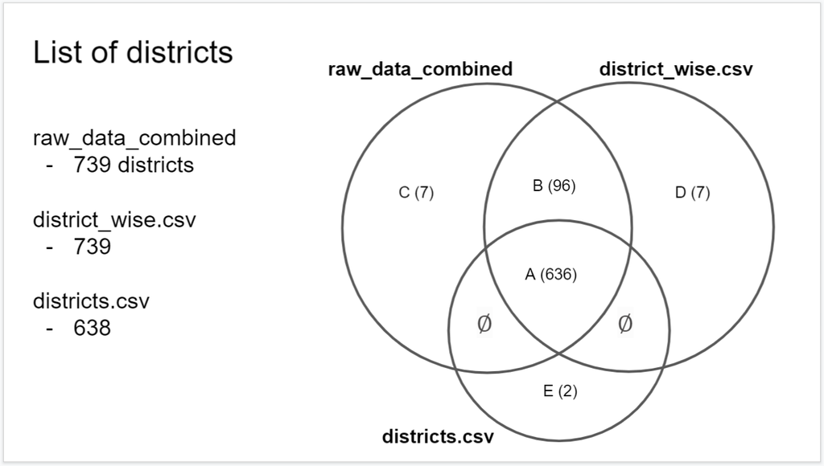

Summary of Districts List

```r
A <- intersect(dr, dd) %>% intersect(ddw)
A
```

```
##   [1] "Thrissur"                    "Alappuzha"
##   [3] "Kasaragod"                   "Others"
##   [5] "Agra"                        "Ghaziabad"
##   [7] "Leh"                         "Kancheepuram"
##   [9] "Pathanamthitta"              "Jammu"
##  [11] "Bengaluru Urban"             "Kannur"
##  [13] "Pune"                        "Amritsar"
##  [15] "Ernakulam"                   "Kottayam"
##  [17] "Jaipur"                      "Mumbai"
##  [19] "Nagpur"                      "S.p.s. Nellore"
##  [21] "Lucknow"                     "Kalaburagi"
##  [23] "Thiruvananthapuram"          "Ahmednagar"
##  [25] "Thane"                       "Raigad"
##  [27] "Yavatmal"                    "Idukki"
##  [29] "Aurangabad (Maharashtra)"    "Dehradun"
```

[output cut: 303 more lines]

```r
B <-intersect(dr, ddw)[!(intersect(dr, ddw) %in% A)]
B
```

```
##  [1] "East Delhi"               "Hyderabad"
##  [3] "South West Delhi"         "West Delhi"
##  [5] "North Delhi"              "New Delhi"
##  [7] "South Delhi"              "North East Delhi"
##  [9] "North West Delhi"         "Karimnagar"
## [11] "Bhadradri Kothagudem"     "Imphal West"
## [13] "Ranga Reddy"              "North Goa"
## [15] "South Andaman"            "Medchal Malkajgiri"
## [17] "North And Middle Andaman" "Cachar"
## [19] "Kamrup Metropolitan"      "Jorhat"
## [21] "Goalpara"                 "Imphal East"
## [23] "Nalbari"                  "South Salmara Mankachar"
## [25] "Rajanna Sircilla"         "Khammam"
## [27] "Warangal Urban"           "Vikarabad"
## [29] "Suryapet"                 "Siddipet"
```

[output cut: 33 more lines]

```r
C <- dr[!(dr %in% c(dd, ddw))]
C
```

```
## [1] "Lmora"        "Kamrup Rural" "Tengunoupal"  "Saraikela"    "Bokara"
## [6] "Gamla"        "Tinsukla"
```

```r
D <- ddw[!(ddw %in% c(dr, dd))]
D
```

```
## [1] "Nicobars"         "Central Delhi"    "Shahdara"         "South East Delhi"
## [5] "Mirpur"           "Muzaffarabad"     "Mumbai Suburban"
```

```r
E <- dd[!(dd %in% c(dr, ddw))]
E
```

```
## [1] "Delhi"           "Capital Complex"
```

The districts in C, let’s check if they are actual districts or just typos.

```r
raw_data_combined %>% filter(detected_district== 'Lmora') # -> ALmora or remove
```

```
## # A tibble: 2 x 13
##   entry_id patient_number date_announced age_bracket gender detected_city
##   <lgl>             <dbl> <chr>          <chr>       <chr>  <chr>
## 1 NA                   NA 30/11/2020     <NA>        <NA>   <NA>
## 2 NA                   NA 30/11/2020     <NA>        <NA>   <NA>
## # ... with 7 more variables: detected_district <chr>, detected_state <chr>,
## #   state_code <chr>, num_cases <dbl>, current_status <chr>,
## #   contracted_from_which_patient_suspected <chr>, notes <chr>
```

```r
raw_data_combined %>% filter(detected_district== 'Kamrup Rural')# -> Kamrup
```

```
## # A tibble: 1 x 13
##   entry_id patient_number date_announced age_bracket gender detected_city
##   <lgl>             <dbl> <chr>          <chr>       <chr>  <chr>
## 1 NA                   NA 13/12/2020     <NA>        <NA>   <NA>
## # ... with 7 more variables: detected_district <chr>, detected_state <chr>,
## #   state_code <chr>, num_cases <dbl>, current_status <chr>,
## #   contracted_from_which_patient_suspected <chr>, notes <chr>
```

```r
raw_data_combined %>% filter(detected_district== 'Tengunoupal')# -> Tengnoupal
```

```
## # A tibble: 1 x 13
##   entry_id patient_number date_announced age_bracket gender detected_city
##   <lgl>             <dbl> <chr>          <chr>       <chr>  <chr>
## 1 NA                   NA 18/12/2020     <NA>        <NA>   <NA>
## # ... with 7 more variables: detected_district <chr>, detected_state <chr>,
## #   state_code <chr>, num_cases <dbl>, current_status <chr>,
## #   contracted_from_which_patient_suspected <chr>, notes <chr>
```

```r
raw_data_combined %>% filter(detected_district== 'Saraikela')# -> Saraikela-Kharsawan or remove.
```

```
## # A tibble: 2 x 13
##   entry_id patient_number date_announced age_bracket gender detected_city
##   <lgl>             <dbl> <chr>          <chr>       <chr>  <chr>
## 1 NA                   NA 17/02/2021     <NA>        <NA>   <NA>
## 2 NA                   NA 17/02/2021     <NA>        <NA>   <NA>
## # ... with 7 more variables: detected_district <chr>, detected_state <chr>,
## #   state_code <chr>, num_cases <dbl>, current_status <chr>,
## #   contracted_from_which_patient_suspected <chr>, notes <chr>
```

```r
raw_data_combined %>% filter(detected_district== 'Bokara')#-> Bokaro or remove
```

```
## # A tibble: 2 x 13
##   entry_id patient_number date_announced age_bracket gender detected_city
##   <lgl>             <dbl> <chr>          <chr>       <chr>  <chr>
## 1 NA                   NA 17/02/2021     <NA>        <NA>   <NA>
## 2 NA                   NA 17/02/2021     <NA>        <NA>   <NA>
## # ... with 7 more variables: detected_district <chr>, detected_state <chr>,
## #   state_code <chr>, num_cases <dbl>, current_status <chr>,
## #   contracted_from_which_patient_suspected <chr>, notes <chr>
```

```r
raw_data_combined %>% filter(detected_district== 'Gamla')# -> Gumla or remove
```

```
## # A tibble: 2 x 13
##   entry_id patient_number date_announced age_bracket gender detected_city
##   <lgl>             <dbl> <chr>          <chr>       <chr>  <chr>
## 1 NA                   NA 26/05/2021     <NA>        <NA>   <NA>
## 2 NA                   NA 26/05/2021     <NA>        <NA>   <NA>
## # ... with 7 more variables: detected_district <chr>, detected_state <chr>,
## #   state_code <chr>, num_cases <dbl>, current_status <chr>,
## #   contracted_from_which_patient_suspected <chr>, notes <chr>
```

```r
raw_data_combined %>% filter(detected_district== 'Tinsukla')# -> Tinsukia
```

```
## # A tibble: 2 x 13
##   entry_id patient_number date_announced age_bracket gender detected_city
##   <lgl>             <dbl> <chr>          <chr>       <chr>  <chr>
## 1 NA                   NA 07/06/2021     <NA>        <NA>   <NA>
## 2 NA                   NA 08/06/2021     <NA>        <NA>   <NA>
## # ... with 7 more variables: detected_district <chr>, detected_state <chr>,
## #   state_code <chr>, num_cases <dbl>, current_status <chr>,
## #   contracted_from_which_patient_suspected <chr>, notes <chr>
```

The results above show that th districts in C are all typos. For example, ‘Tinsukla’ should’ve been coded as ‘Tinsukia’. If you check ‘Tinsukia’ rows in `raw_data_combined`, you can see that data on 07/06/2021 and 08/06/2021 are ommited because they are coded as ‘Tinsukla’. Let’s fix them.

```r
raw_data_combined <- raw_data_combined[which(raw_data_combined$detected_district != 'Lmora'),]
raw_data_combined[which(raw_data_combined$detected_district == 'Kamrup Rural'),]$detected_district <-
  'Kamrup'
raw_data_combined[which(raw_data_combined$detected_district == 'Tengunoupal'),]$detected_district <-
  'Tengnoupal'
raw_data_combined <- raw_data_combined[which(raw_data_combined$detected_district != 'Saraikela'),]
raw_data_combined <- raw_data_combined[which(raw_data_combined$detected_district != 'Bokara'),]
raw_data_combined <- raw_data_combined[which(raw_data_combined$detected_district != 'Gamla'),]
raw_data_combined[which(raw_data_combined$detected_district == 'Tinsukla'),]$detected_district <-
  'Tinsukia'
```

The lists of districts should be like these :

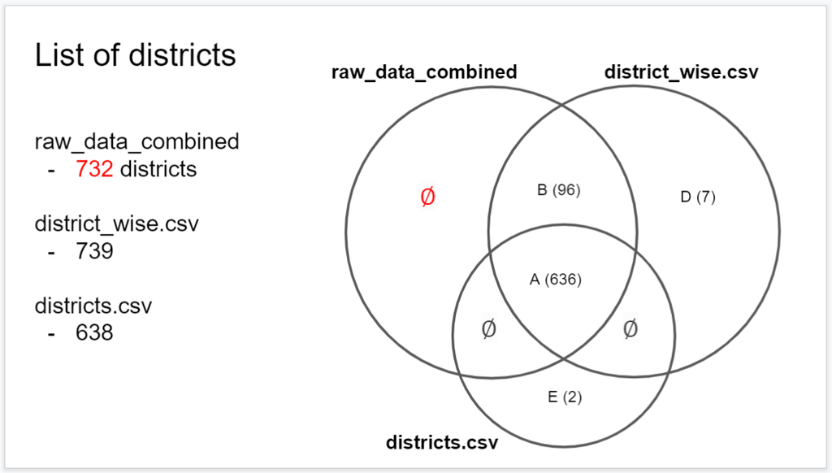

Summary of Districts List

```r
dr <- unique(raw_data_combined$detected_district) #list of districts in 'raw_data_combined' : 732 districts.
dd <- unique(districts$District) #list of districts in 'districts.csv' : 638 districts.
ddw <- unique(district_wise$District) #list of districts in 'district_wise.csv' : 739 districts.

A <- intersect(dr, dd) %>% intersect(ddw)
B <-intersect(dr, ddw)[!(intersect(dr, ddw) %in% A)]
C <- dr[!(dr %in% c(dd, ddw))]
D <- ddw[!(ddw %in% c(dr, dd))]
E <- dd[!(dd %in% c(dr, ddw))]
```

Let’s see what data in D and E look like.

```r
#D
district_wise %>% filter(District %in% D) %>% .[,c(1:8, 14)]
```

```
## # A tibble: 7 x 9
##   State_Code State District_Key District Confirmed Active Recovered Deceased
##   <chr>      <chr> <chr>        <chr>        <dbl>  <dbl>     <dbl>    <dbl>
## 1 AN         Anda~ AN_Nicobars  Nicobars         0      0         0        0
## 2 DL         Delhi DL_Central ~ Central~       184    184         0        0
## 3 DL         Delhi DL_Shahdara  Shahdara        48     48         0        0
## 4 DL         Delhi DL_South Ea~ South E~       130    130         0        0
## 5 JK         Jamm~ JK_Mirpur    Mirpur           0      0         0        0
## 6 JK         Jamm~ JK_Muzaffar~ Muzaffa~         0      0         0        0
## 7 MH         Maha~ MH_Mumbai S~ Mumbai ~         0      0         0        0
## # ... with 1 more variable: District_Notes <chr>
```

```r
# E
districts %>% filter(District =='Delhi') %>% nrow()
```

```
## [1] 420
```

```r
districts %>% filter(State =='Delhi') %>% nrow()
```

```
## [1] 420
```

The numbers between rows with state ‘Delhi’ and district ‘Delhi’ are the same. That means district level data of Dellhi is not organized in `districts`. Is district-wise data in Delhi collected in `raw_data_combined`? Actually, not. If you run the following code, you can check that district-level data hasn’t been collected since 06/05/2020.

```r
raw_data_combined %>% filter(detected_state == "Delhi") %>% View()
raw_data_combined %>% filter(detected_state == "Delhi" &
                               detected_district != 'Others') %>% View()
```

```r
# E
districts %>% filter(District =='Capital Complex') %>% head(30) # No COVID cases...?
```

```
## # A tibble: 30 x 8
##    Date       State        District    Confirmed Recovered Deceased Other Tested
##    <date>     <chr>        <chr>           <dbl>     <dbl>    <dbl> <dbl>  <dbl>
##  1 2020-06-01 Arunachal P~ Capital Co~         0         0        0     0   1062
##  2 2020-06-02 Arunachal P~ Capital Co~         0         0        0     0   1062
##  3 2020-06-03 Arunachal P~ Capital Co~         0         0        0     0   1190
##  4 2020-06-04 Arunachal P~ Capital Co~         0         0        0     0   1218
##  5 2020-06-05 Arunachal P~ Capital Co~         0         0        0     0   1381
##  6 2020-06-06 Arunachal P~ Capital Co~         0         0        0     0   1381
##  7 2020-06-07 Arunachal P~ Capital Co~         0         0        0     0   1574
##  8 2020-06-08 Arunachal P~ Capital Co~         0         0        0     0   1625
##  9 2020-06-09 Arunachal P~ Capital Co~         0         0        0     0   1723
## 10 2020-06-10 Arunachal P~ Capital Co~         0         0        0     0   1723
## # ... with 20 more rows
```

Highlight districts that are missing across the datasets for all combinations of the three datasets. The full list of states and districts will be loaded and saved as `lists`. This data is from https://www.askbankifsccode.com/blog/list-of-all-states-union-territories-and-districts-in-india/ . First, I will make the duplicated district names unique as above.

```r
lists <- read_csv(here("outcome/Indian-States-and-Districts-List.csv"))
lists %>% group_by(District) %>% summarise(n = n()) %>% filter(n > 1)
```

```
## # A tibble: 5 x 2
##   District       n
##   <chr>      <int>
## 1 Aurangabad     2
## 2 Balrampur      2
## 3 Bilaspur       2
## 4 Hamirpur       2
## 5 Pratapgarh     2
```

```r
multiple_dist <- lists %>% group_by(District) %>% summarise(n = n()) %>% filter(n > 1)

#Make states column
multiple_dist$states <- NA
for (i in 1:nrow(multiple_dist)) {
  dist <- multiple_dist$District[i]
  multiple_dist$states[i] <-
    lists %>% group_by(District, State) %>% summarise(n = n()) %>%
    filter(District == dist) %>% .$State %>% list()
}
multiple_dist$states2 <- lapply(multiple_dist$states, function(x) paste0(x, collapse = ", ")) %>%
  unlist()
multiple_dist
```

```
## # A tibble: 5 x 4
##   District       n states    states2
##   <chr>      <int> <list>    <chr>
## 1 Aurangabad     2 <chr [2]> Bihar, Maharashtra
## 2 Balrampur      2 <chr [2]> Chhattisgarh, Uttar Pradesh
## 3 Bilaspur       2 <chr [2]> Chhattisgarh, Himachal Pradesh
## 4 Hamirpur       2 <chr [2]> Himachal Pradesh, Uttar Pradesh
## 5 Pratapgarh     2 <chr [2]> Rajasthan, Uttar Pradesh
```

```r
#Assign unique district names.
for (i in 1:nrow(multiple_dist)){
  dist <- multiple_dist$District[i]
  state_list <- multiple_dist$states[[i]]

  for (state in state_list){
    lists[which(lists$District==dist &
                          lists$State == state),]$District <-
      paste0(dist, ' (', state, ')')
    }
}
```

```r
dc <- unique(c(dr, dd, ddw)) #districts of all combinations of the three.
length(dc)
```

```
## [1] 741
```

```r
intersect(dc, lists$District) %>% length()
```

```
## [1] 678
```

```r
dc[!(dc %in% lists$District)]
```

```
##  [1] "Others"                    "Kancheepuram"
##  [3] "Bengaluru Urban"           "Mumbai"
##  [5] "S.p.s. Nellore"            "Kalaburagi"
##  [7] "Lakhimpur Kheri"           "Shahid Bhagat Singh Nagar"
##  [9] "S.a.s. Nagar"              "Chikkaballapura"
## [11] "Mysuru"                    "Pauri Garhwal"
## [13] "Medchal Malkajgiri"        "North And Middle Andaman"
## [15] "Tumakuru"                  "Shopiyan"
## [17] "Ballari"                   "Thoothukkudi"
## [19] "Y.s.r. Kadapa"             "Tirupathur"
## [21] "Thiruvarur"                "Thiruvallur"
## [23] "Bagalkote"                 "Nuh"
## [25] "South Salmara Mankachar"   "Belagavi"
## [27] "Mahabubnagar"              "Bengaluru Rural"
## [29] "Rae Bareli"                "Jogulamba Gadwal"
```

[output cut: 17 more lines]

Some districts have multiple names. To match the subtle differences of district names, I added a new column ‘District2’ in “outcome/Indian-States-and-Districts-List.csv”.

```r
dc[!(dc %in% lists$District) & !(dc %in% lists$District2)]
```

```
## [1] "Others"          "Nuh"             "Bsf Camp"        "Capf Personnel"
## [5] "Delhi"           "Capital Complex" "Mirpur"          "Muzaffarabad"
```

List of districts that are missing across the datasets for all combinations of the three datasets is as follows.

```r
lists$District[!(lists$District %in% dc) & !(lists$District2 %in% dc)]
```

```
## [1] "Bajali"         "Mewat"          "Vijayanagara"   "Chachaura"
## [5] "Maihar"         "Nagda"          "Noklak"         "Mayiladuthurai"
```

# Check how different values in `raw_data_combined` and `districts.csv`.

Make a table that shows the percentage difference for the categories(Hospitalized, Recovered or Deceased). Let’s make the table and save it as `diff`. The list of districts that are contained in both `raw_data_combined` and `districts.csv` is saved in `A`. However, district ‘Others’ will not be used.

```r
A_ <- A[A != 'Others'] # A except 'Others'
len <- length(A_)

diff <- data.frame(A_, ExactSame = rep(NA, len), Hospitalized_raw = rep(NA, len),
                   Recovered_raw = rep(NA, len), Deceased_raw = rep(NA, len),

                   Hospitalized_districts = rep(NA, len), Recovered_districts = rep(NA, len),
                   Deceased_districts= rep(NA, len),

                   Hospitalized_perdiff = rep(NA, len), Recovered_perdiff = rep(NA, len),
                   Deceased_perdiff = rep(NA, len))

for (i in 1: nrow(diff)){
  dist <- diff[i,1]

  cases_districts <- districts %>% filter(District == dist) %>% tail(1) %>% .[,c(4:6)]

  cases_raw <- c(
    raw_data_combined %>% filter(detected_district == dist, current_status == "Hospitalized") %>%
    .$num_cases %>% sum(na.rm = TRUE),

    raw_data_combined %>% filter(detected_district == dist, current_status == "Recovered") %>%
    .$num_cases %>% sum(na.rm = TRUE),

    raw_data_combined %>% filter(detected_district == dist, current_status == "Deceased") %>%
    .$num_cases %>% sum(na.rm = TRUE)
    )

  cases_diff <- cases_districts - cases_raw

  diff[i,2] <- all(cases_diff==0)

  diff[i, 3:5] <- cases_raw
  diff[i, 6:8] <- cases_districts
  diff[i, 9:11] <- cases_diff/cases_raw * 100
}
```

For several districts, deceased cases are both zero in `raw_data_combined` and `districts`. 0/0 returns NaN in R. Since that means exact match between the two data sets, I will change NaN in `Deceased_perdiff` to 0.

```r
tail(diff) #When Deceased_raw and Deceased_districts are both 0, Deceased_perdiff is NaN.
```

```
##                         A_ ExactSame Hospitalized_raw Recovered_raw
## 630              Hnahthial      TRUE               29            25
## 631 South West Khasi Hills      TRUE              901           588
## 632    Upper Dibang Valley      TRUE              200           187
## 633              Kra Daadi      TRUE              166           110
## 634           Kurung Kumey      TRUE              290           175
## 635            Lakshadweep      TRUE             9430          9003
##     Deceased_raw Hospitalized_districts Recovered_districts Deceased_districts
## 630            0                     29                  25                  0
## 631            3                    901                 588                  3
## 632            1                    200                 187                  1
## 633            0                    166                 110                  0
## 634            0                    290                 175                  0
## 635           46                   9430                9003                 46
##     Hospitalized_perdiff Recovered_perdiff Deceased_perdiff
## 630                    0                 0              NaN
## 631                    0                 0                0
## 632                    0                 0                0
## 633                    0                 0              NaN
## 634                    0                 0              NaN
## 635                    0                 0                0
```

```r
#Let's change NaN to 0.
diff[is.nan(diff$Deceased_perdiff), ]$Deceased_perdiff <- 0
```

Out of the 635 districts, how many districts have the same number of cases for the three categories?

```r
sum(diff$ExactSame == TRUE)
```

```
## [1] 308
```

Out of the 327(=635-308) districts, which districts have the maximal percentage differences for the three categories?

```r
diff[which(abs(diff$Hospitalized_perdiff) == max(abs(diff$Hospitalized_perdiff))),]
```

```
##                A_ ExactSame Hospitalized_raw Recovered_raw Deceased_raw
## 505 Churachandpur     FALSE             4324            58           75
## 535     Dibrugarh     FALSE            27787          2409          279
## 538      Udalguri     FALSE             3994           666           54
##     Hospitalized_districts Recovered_districts Deceased_districts
## 505                      0                   0                  0
## 535                      0                   0                  0
## 538                      0                   0                  0
##     Hospitalized_perdiff Recovered_perdiff Deceased_perdiff
## 505                 -100              -100             -100
## 535                 -100              -100             -100
## 538                 -100              -100             -100
```

```r
diff[which(abs(diff$Recovered_perdiff) == max(abs(diff$Recovered_perdiff))),]
```

```
##                A_ ExactSame Hospitalized_raw Recovered_raw Deceased_raw
## 505 Churachandpur     FALSE             4324            58           75
## 535     Dibrugarh     FALSE            27787          2409          279
## 538      Udalguri     FALSE             3994           666           54
##     Hospitalized_districts Recovered_districts Deceased_districts
## 505                      0                   0                  0
## 535                      0                   0                  0
## 538                      0                   0                  0
##     Hospitalized_perdiff Recovered_perdiff Deceased_perdiff
## 505                 -100              -100             -100
## 535                 -100              -100             -100
## 538                 -100              -100             -100
```

```r
diff[which(abs(diff$Deceased_perdiff) == max(abs(diff$Deceased_perdiff))),]
```

```
##                A_ ExactSame Hospitalized_raw Recovered_raw Deceased_raw
## 505 Churachandpur     FALSE             4324            58           75
## 535     Dibrugarh     FALSE            27787          2409          279
## 538      Udalguri     FALSE             3994           666           54
##     Hospitalized_districts Recovered_districts Deceased_districts
## 505                      0                   0                  0
## 535                      0                   0                  0
## 538                      0                   0                  0
##     Hospitalized_perdiff Recovered_perdiff Deceased_perdiff
## 505                 -100              -100             -100
## 535                 -100              -100             -100
## 538                 -100              -100             -100
```

Churachandpur, Dibrugarh, and Udalguri has 0 for the three categories, so they have the maximal differences. What if we exclude them and see which distircts have the biggest differences?

```r
diff2 <- diff[!(diff$A_ %in% c("Churachandpur", "Dibrugarh", "Udalguri")), ] #exclude the three districts.

#Five districts with the largest percentage difference of 'Hospitalized'
diff2 %>% arrange(desc(Hospitalized_perdiff)) %>% head(5)
```

```
##                A_ ExactSame Hospitalized_raw Recovered_raw Deceased_raw
## 1       Kalimpong     FALSE             5444          5203           38
## 2          Howrah     FALSE            91792         88899         1443
## 3       Burhanpur     FALSE             2566          2529           39
## 4         Kolkata     FALSE           306067        299295         4833
## 5 Purba Medinipur     FALSE            56870         54026          354
##   Hospitalized_districts Recovered_districts Deceased_districts
## 1                   5451                5203                 37
## 2                  91871               88899               1442
## 3                   2568                2529                 39
## 4                 306243              299293               4832
## 5                  56889               54026                354
##   Hospitalized_perdiff Recovered_perdiff Deceased_perdiff
## 1           0.12858193       0.000000000      -2.63157895
## 2           0.08606415       0.000000000      -0.06930007
## 3           0.07794232       0.000000000       0.00000000
## 4           0.05750375      -0.000668237      -0.02069108
## 5           0.03340953       0.000000000       0.00000000
```

```r
#Five districts with the largest percentage difference of 'Recovered'
diff2 %>% arrange(desc(Recovered_perdiff)) %>% head(5)
```

```
##          A_ ExactSame Hospitalized_raw Recovered_raw Deceased_raw
## 1       Nuh     FALSE             4987          4827          110
## 2      Tonk     FALSE             9432          9213           91
## 3   Khandwa     FALSE             4040          3930           93
## 4    Palwal     FALSE            10636         10427          146
## 5 Bandipora     FALSE             9129          8702           98
##   Hospitalized_districts Recovered_districts Deceased_districts
## 1                   4987                4866                110
## 2                   9432                9245                 92
## 3                   4040                3942                 94
## 4                  10636               10456                146
## 5                   9130                8725                 98
##   Hospitalized_perdiff Recovered_perdiff Deceased_perdiff
## 1            0.0000000         0.8079553         0.000000
## 2            0.0000000         0.3473353         1.098901
## 3            0.0000000         0.3053435         1.075269
## 4            0.0000000         0.2781241         0.000000
## 5            0.0109541         0.2643071         0.000000
```

```r
#Five districts with the largest percentage difference of 'Deceased'
diff2 %>% arrange(desc(Deceased_perdiff)) %>% head(5)
```

```
##          A_ ExactSame Hospitalized_raw Recovered_raw Deceased_raw
## 1     Dewas     FALSE             7723          7662           45
## 2    Ujjain     FALSE            18878         18658          155
## 3     Anand     FALSE             9568          9467           44
## 4    Indore     FALSE           152734        150815         1319
## 5 Ahmedabad     FALSE           237389        232380         3289
##   Hospitalized_districts Recovered_districts Deceased_districts
## 1                   7723                7666                 51
## 2                  18879               18663                171
## 3                   9568                9481                 47
## 4                 152735              150922               1375
## 5                 237391              232519               3392
##   Hospitalized_perdiff Recovered_perdiff Deceased_perdiff
## 1         0.0000000000        0.05220569        13.333333
## 2         0.0052971713        0.02679816        10.322581
## 3         0.0000000000        0.14788212         6.818182
## 4         0.0006547331        0.07094785         4.245641
## 5         0.0008424990        0.05981582         3.131651
```

Kalimpong has the largest percentage difference for hospotalized cases, and it’s 0.13%. For the recovered cases, Nuh has the biggest difference with 0.81%. The differences were more significant in the deceased cases. Dewas shows 13.3% differences.

# Check which districts in `district_wise` have the warning message

(District-wise numbers are out-dated as cummulative counts for each district are not reported in bulletin or have complete 0 count across all categories.) Make note of which states these districts belong to. Check if COVID numbers for those districts are reported in `raw_data_combined` and `districts`. Even though the numbers are reported, check if there is any note for those districts.

```r
#See messages in District_Notes
unique(district_wise$District_Notes)
```

```
##  [1] NA
##  [2] "District-wise numbers are out-dated as cumulative counts for each district are not reported in bulletin"
##  [3] "One death of COVID-19 positive patient has occured due to non-covid reasons"
##  [4] "Death of Tibetan refugee on March 22 included in Kangra district's tally"
##  [5] "[Sep 9]After reconciling COVID-19 cases in Mumbai, owing to the removal of duplicates and change of addresses as per the original residence, 239 cases have been removed from the progressive figures."
##  [6] "District administration provides number of persons tested instead of the number of samples tested."
##  [7] "Number of active cases differs in the state bulletin and district bulletin. We follow the state bulletin."
##  [8] "2 case of TN has been transferred,so has been reduced from the total count."
##  [9] "1 case of KL have been transferred,so have been reduced from the total count"
## [10] "209 cases(204 of TN, 1 of AP and 4 other) have been transferred,so have been reduced from the total count.[July 18]4 cases have transferred to TN and have been reduced from recovered cases."
## [11] "2 cases of AP have been transferred,so have been reduced from the total count"
## [12] "District-wise numbers are out-dated as cumulative counts for each district are not reported in Telangana bulletin"
## [13] "[July 22]: 444 backdated deceased entries added to Chennai in TN bulletin."
```

```r
#Messages we want to focus on :
mes <- c("District-wise numbers are out-dated as cumulative counts for each district are not reported in bulletin", "District-wise numbers are out-dated as cumulative counts for each district are not reported in Telangana bulletin")

district_wise %>% filter(District_Notes %in% mes)
```

```
## # A tibble: 52 x 15
##    State_Code State District_Key District Confirmed Active Recovered Deceased
##    <chr>      <chr> <chr>        <chr>        <dbl>  <dbl>     <dbl>    <dbl>
##  1 AN         Anda~ AN_Nicobars  Nicobars         0      0         0        0
##  2 AN         Anda~ AN_North an~ North A~         1      0         1        0
##  3 AN         Anda~ AN_South An~ South A~        51     19        32        0
##  4 DL         Delhi DL_Central ~ Central~       184    184         0        0
##  5 DL         Delhi DL_East Del~ East De~        38     38         0        0
##  6 DL         Delhi DL_New Delhi New Del~        37     37         0        0
##  7 DL         Delhi DL_North De~ North D~        60     60         0        0
##  8 DL         Delhi DL_North Ea~ North E~        25     25         0        0
##  9 DL         Delhi DL_North We~ North W~        32     31         0        1
## 10 DL         Delhi DL_Shahdara  Shahdara        48     48         0        0
## # ... with 42 more rows, and 7 more variables: Migrated_Other <dbl>,
## #   Delta_Confirmed <dbl>, Delta_Active <dbl>, Delta_Recovered <dbl>,
## #   Delta_Deceased <dbl>, District_Notes <chr>, Last_Updated <lgl>
```

```r
states_mes <- c("Andaman and Nicobar Islands", "Delhi", "Goa", "Telangana")
district_wise %>% filter(State %in% states_mes)
```

```
## # A tibble: 56 x 15
##    State_Code State District_Key District Confirmed Active Recovered Deceased
##    <chr>      <chr> <chr>        <chr>        <dbl>  <dbl>     <dbl>    <dbl>
##  1 AN         Anda~ AN_Nicobars  Nicobars         0      0         0        0
##  2 AN         Anda~ AN_North an~ North A~         1      0         1        0
##  3 AN         Anda~ AN_South An~ South A~        51     19        32        0
##  4 DL         Delhi DL_Central ~ Central~       184    184         0        0
##  5 DL         Delhi DL_East Del~ East De~        38     38         0        0
##  6 DL         Delhi DL_New Delhi New Del~        37     37         0        0
##  7 DL         Delhi DL_North De~ North D~        60     60         0        0
##  8 DL         Delhi DL_North Ea~ North E~        25     25         0        0
##  9 DL         Delhi DL_North We~ North W~        32     31         0        1
## 10 DL         Delhi DL_Shahdara  Shahdara        48     48         0        0
## # ... with 46 more rows, and 7 more variables: Migrated_Other <dbl>,
## #   Delta_Confirmed <dbl>, Delta_Active <dbl>, Delta_Recovered <dbl>,
## #   Delta_Deceased <dbl>, District_Notes <chr>, Last_Updated <lgl>
```

```r
raw_data_combined %>% filter(detected_state == "Andaman and Nicobar Islands") %>% View()
raw_data_combined %>% filter(detected_state == "Andaman and Nicobar Islands" &
                               detected_district != 'Others') %>% View()

raw_data_combined %>% filter(detected_state == "Delhi") %>% View()
raw_data_combined %>% filter(detected_state == "Delhi" &
                               detected_district != 'Others') %>% View()

raw_data_combined %>% filter(detected_state == "Goa") %>% View()
raw_data_combined %>% filter(detected_state == "Goa" &
                               detected_district != 'Others') %>% View()

raw_data_combined %>% filter(detected_state == "Telangana") %>% View()
raw_data_combined %>% filter(detected_state == "Telangana" &
                               detected_district != 'Others') %>% View()
```

For the list of districts in `B`, are they included in one of the states above(Andaman and Nicobar Islands, Delhi, Goa, or Telangana)? The districts in `B` are removed in `districts` because of their out-dated data? Not every district. They are inlcuded in one of the following states : (Andaman and Nicobar Islands, Delhi, Goa, Telangana, Assam, Manipur, or Sikkim)

```r
B[!(B %in% c(lists$District, lists$District2))]
```

```
## [1] "Capf Personnel"
```

```r
lists[lists$District %in% B | lists$District2 %in% B , ]
```

```
## # A tibble: 95 x 4
##    State           District             `State Type`    District2
##    <chr>           <chr>                <chr>           <chr>
##  1 Andaman Nicobar North Middle Andaman Union Territory North And Middle Andaman
##  2 Andaman Nicobar South Andaman        Union Territory <NA>
##  3 Assam           Baksa                State           <NA>
##  4 Assam           Barpeta              State           <NA>
##  5 Assam           Biswanath            State           <NA>
##  6 Assam           Bongaigaon           State           <NA>
##  7 Assam           Cachar               State           <NA>
##  8 Assam           Charaideo            State           <NA>
##  9 Assam           Chirang              State           <NA>
## 10 Assam           Darrang              State           <NA>
## # ... with 85 more rows
```

```r
lists[lists$District %in% B | lists$District2 %in% B , ]$State %>% unique()
```

```
## [1] "Andaman Nicobar" "Assam"           "Delhi"           "Goa"
## [5] "Manipur"         "Sikkim"          "Telangana"
```

It looks like districts in Assam, Manipur, or Sikkim are excluded in `districts` for no reason.

```r
raw_data_combined %>% filter(detected_state == "Assam") %>% View()
raw_data_combined %>% filter(detected_state == "Assam" &
                               detected_district != 'Others') %>% View()

raw_data_combined %>% filter(detected_state == "Manipur") %>% View()
raw_data_combined %>% filter(detected_state == "Manipur" &
                               detected_district != 'Others') %>% View()

raw_data_combined %>% filter(detected_state == "Assam") %>% View()
raw_data_combined %>% filter(detected_state == "Assam" &
                               detected_district != 'Others') %>% View()
```